# Midterm Project — Exploratory Data Analysis on BSEE Well Data

**Course:** Data Science  
**Team:** Group 9  
**Team Manager:** Nisarg Shah

**Team members:**  
Omkar Vasudeo Koli [2488159]  
Nisarg Shah [2450291]  
Praveen Kumar G [2492402]  
Parva Shah [2480044]  
Nithin Lingala [2510610]

## Problem Statement

The offshore energy industry generates vast amounts of drilling and well data, which often remain underutilized due to their size and complexity. Understanding patterns in well performance, geographical characteristics, and company operations is critical for optimizing exploration and production.

This project focuses on analyzing **BSEE (Bureau of Safety and Environmental Enforcement) Well Data**, aiming to clean, explore, and visualize information from thousands of wells. By applying Exploratory Data Analysis (EDA) techniques, the goal is to uncover patterns, detect anomalies, and develop insights that could assist in data-driven decision-making for the oil and gas sector.

## Objectives

1. **Understand the dataset** — identify key columns, data types, and completeness.
2. **Perform Exploratory Data Analysis (EDA)** at univariate, bivariate, and multivariate levels.
3. **Visualize patterns** in depth, location, company operations, and production-related attributes.
4. **Detect data issues** such as missing values, inconsistencies, or extreme outliers.
5. **Summarize insights** that can support future predictive modeling or decision processes.

## Data Description

The dataset comprises approximately **20,000 well records** collected from the Bureau of Safety and Environmental Enforcement (BSEE). It includes **geospatial, operational, and company-level information** about each well.

[output not shown]

**Dataset Highlights:**

- Contains **20,000 rows** with a mixture of numeric and categorical data.
- Includes both **location-based** and **operation-based** attributes.
- Contains missing values in some columns such as *KOP* and *Spud Date*.
- Rich diversity in company names, locations, and lease identifiers.
- Ready for EDA involving geospatial, temporal, and categorical analysis.

## Ethical and Privacy Considerations

This dataset is publicly available through BSEE’s open data portal and does not contain personally identifiable information. It is used purely for academic and analytical purposes to demonstrate data science techniques.

> In the following sections, we perform Webscraping of our data from BSEE website and then we proceed for an in-depth exploratory data analysis (EDA) on this dataset, including visualizations, correlation analysis, and trend detection to uncover actionable insights.

```python
!apt-get update
!apt-get install -y chromium-browser chromium-chromedriver
!pip install selenium webdriver-manager bs4 pandas lxml
```

[output not shown]

```python
# --- CONFIGURATION ---

# 1. Mount Google Drive
try:
    from google.colab import drive
    drive.mount('/content/drive')
    print("Google Drive mounted successfully.")
except Exception as e:
    print(f"Error mounting Google Drive: {e}")
    print("Scraping will not proceed without Google Drive.")

# 2. Correct output path
DRIVE_OUTPUT_FILE = "/content/drive/MyDrive/DS-project/bsee_well_data.csv"

print("Output file will be saved to:", DRIVE_OUTPUT_FILE)

# Create folder if missing
!mkdir -p "/content/drive/MyDrive/DS-project"
```

```
Google Drive mounted successfully.
Output file will be saved to: /content/drive/MyDrive/DS-project/bsee_well_data.csv
```

```python
import csv
import time
import os
import pandas as pd
from bs4 import BeautifulSoup
from selenium import webdriver
from selenium.webdriver.common.by import By
from selenium.webdriver.support.ui import WebDriverWait
from selenium.webdriver.support import expected_conditions as EC
from selenium.common.exceptions import TimeoutException, NoSuchElementException
from google.colab import drive
```

## Webscraping

```python
# Target number of rows to scrape.
TARGET_ROW_COUNT = 20000

# Base URL for the BSEE Well Information query page
BASE_URL = "https://data.bsee.gov/Well/Borehole/Default.aspx"

# Politeness delay between paged requests (in seconds)
POLITENESS_DELAY = 1.0 # Increased delay slightly for page reloads

# --- SCRIPT ---

class BSEEScraper:
    """
    A scraper for the BSEE Well Information database.

    Handles ASP.NET postbacks using Selenium to execute JavaScript.
    This version changes page size to 200, clicks "Next" for pagination,
    and saves data progressively to make it more robust against failures.
    """

    def __init__(self):
        self.header_data = []
        self.total_rows_scraped = 0

        # --- Selenium Setup for Colab ---
        options = webdriver.ChromeOptions()

        # --- Stealth Options to avoid detection ---
        user_agent = "Mozilla/5.0 (Windows NT 10.0; Win64; x64) AppleWebKit/5.2 (KHTML, like Gecko) Chrome/120.0.0.0 Safari/537.36"
        options.add_argument(f'user-agent={user_agent}')

        options.add_argument('--headless')
        options.add_argument('--no-sandbox')
        options.add_argument('--disable-dev-shm-usage')
        options.add_argument('--disable-blink-features=AutomationControlled')
        options.add_experimental_option("excludeSwitches", ["enable-automation"])
        options.add_experimental_option('useAutomationExtension', False)

        try:
            # Use the system-installed chromedriver in Colab
            self.driver = webdriver.Chrome(options=options)

            self.driver.execute_script("Object.defineProperty(navigator, 'webdriver', {get: () => undefined})")

            print("WebDriver initialized successfully in headless, stealth mode.")
        except Exception as e:
            print(f"Error initializing WebDriver: {e}")
            print("Please ensure you have run the setup cell (!pip install selenium, !apt-get install chromium-chromedriver)")
            raise

    def _scrape_table_from_soup(self, soup):
        """Extracts data from the main results table from a BeautifulSoup object."""

        table = soup.find('table', {'id': 'ASPxFormLayout2_ASPxGridView1_DXMainTable'})
        if not table:
            print("Error: Could not find data table ('ASPxFormLayout2_ASPxGridView1_DXMainTable') on page.")
            return []

        # Get header (only on the first run)
        if not self.header_data:
            header_row = table.find('tr', {'id': 'ASPxFormLayout2_ASPxGridView1_DXHeadersRow0'})
            if header_row:
                self.header_data = [th.get_text(strip=True) for th in header_row.find_all('td', class_='dxgvHeader')]
                print(f"Found headers: {self.header_data}")

        # Get data rows
        page_rows = []
        rows = table.find_all('tr', {'class': ['dxgvDataRow', 'dxgvDataRowAlt']})
        for row in rows:
            cols = [td.get_text(strip=True) for td in row.find_all('td', class_='dxgv')]
            if self.header_data and len(cols) == len(self.header_data):
                page_rows.append(cols)
            elif not self.header_data:
                 page_rows.append(cols)

        print(f"Scraped {len(page_rows)} rows from this page.")
        return page_rows

    def _change_page_size_to_200(self):
        """Finds the pager, clicks to open dropdown, and selects '200'."""
        try:
            print("Attempting to set page size to 200...")

            # 1. Find the page size selector box (bottom pager)
            pager_box_id = "ASPxFormLayout2_ASPxGridView1_DXPagerBottom_PSB"
            pager_box = WebDriverWait(self.driver, 10).until(
                EC.element_to_be_clickable((By.ID, pager_box_id))
            )

            # Get a reference to the table to check for staleness
            old_table = self.driver.find_element(By.ID, 'ASPxFormLayout2_ASPxGridView1_DXMainTable')

            # 2. Click the pager box to open the dropdown
            pager_box.click()

            # 3. Wait for the '200' option to be visible and click it
            # The options are in a popup menu, we find them by their text
            option_200 = WebDriverWait(self.driver, 10).until(
                EC.element_to_be_clickable((By.XPATH, "//div[starts-with(@id, 'ASPxFormLayout2_ASPxGridView1_DXPagerBottom_PSP')]//span[text()='200']"))
            )
            option_200.click()

            # 4. Wait for the page to reload (wait for old table to go stale)
            print("Waiting for grid to reload with 200 rows...")
            WebDriverWait(self.driver, 30).until(
                EC.staleness_of(old_table)
            )

            # 5. Wait for the *new* table to be present
            WebDriverWait(self.driver, 30).until(
                EC.presence_of_element_located((By.ID, 'ASPxFormLayout2_ASPxGridView1_DXMainTable'))
            )
            print("Page size successfully set to 200.")
            return True

        except Exception as e:
            print(f"Error changing page size to 200: {e}")
            return False

    def run_scraper(self, output_file_path): # <-- Accept the path as an argument
        """Executes the full scraping process using Selenium."""

        print(f"Starting BSEE Well Scraper. Target: {TARGET_ROW_COUNT} rows.")

        # --- 1. Initial GET to load the page ---
        print(f"Sending initial GET to {BASE_URL}...")
        try:
            self.driver.set_page_load_timeout(60)
            self.driver.get(BASE_URL)
            WebDriverWait(self.driver, 60).until(
                EC.presence_of_element_located((By.ID, 'ASPxFormLayout2_ASPxGridView1_DXMainTable'))
            )
            print("Page loaded and data table is present.")
        except TimeoutException:
            print("Error: Page load timed out. The site might be down or blocking headless browsers.")
            with open("debug_timeout_page.html", "w", encoding="utf-8") as f:
                f.write(self.driver.page_source)
            print("Saved current page source to 'debug_timeout_page.html'")
            self.driver.quit()
            return
        except Exception as e:
            print(f"Error on initial GET or page load: {e}")
            self.driver.quit()
            return

        # --- 2. Change Page Size ---
        if not self._change_page_size_to_200():
            print("Could not change page size. Scraping will proceed with default size.")
            # Continue anyway, it will just be slower

        # --- 3. Open CSV file and Scrape Page 1 ---
        try:
            with open(output_file_path, 'w', newline='', encoding='utf-8') as f: # <-- Use the provided path
                writer = csv.writer(f)

                print("Scraping Page 1...")
                try:
                    soup = BeautifulSoup(self.driver.page_source, 'lxml')
                    page_1_rows = self._scrape_table_from_soup(soup)

                    if self.header_data:
                        writer.writerow(self.header_data)

                    if page_1_rows:
                        writer.writerows(page_1_rows)
                        self.total_rows_scraped += len(page_1_rows)
                        print(f"Total rows scraped: {self.total_rows_scraped}")
                    else:
                        print("Warning: Page 1 loaded but no data was scraped.")

                except Exception as e:
                    print(f"Error on initial scrape: {e}")
                    with open("debug_scrape_fail_page.html", "w", encoding="utf-8") as f:
                        f.write(self.driver.page_source)
                    print("Saved current page source to 'debug_scrape_fail_page.html'")
                    self.driver.quit()
                    return

                # --- 4. Paginate and Scrape by clicking "Next" ---
                page_counter = 1
                while self.total_rows_scraped < TARGET_ROW_COUNT:
                    page_counter += 1
                    print(f"\nRequesting Page {page_counter} (Total Rows: {self.total_rows_scraped})...")
                    time.sleep(POLITENESS_DELAY)

                    try:
                        next_link_id = "ASPxFormLayout2_ASPxGridView1_DXPagerBottom_PBN"

                        next_link = WebDriverWait(self.driver, 10).until(
                            EC.element_to_be_clickable((By.ID, next_link_id))
                        )

                        old_table = self.driver.find_element(By.ID, 'ASPxFormLayout2_ASPxGridView1_DXMainTable')

                        next_link.click()

                        WebDriverWait(self.driver, 20).until(
                            EC.staleness_of(old_table)
                        )

                        WebDriverWait(self.driver, 20).until(
                            EC.presence_of_element_located((By.ID, 'ASPxFormLayout2_ASPxGridView1_DXMainTable'))
                        )

                        soup = BeautifulSoup(self.driver.page_source, 'lxml')
                        new_rows = self._scrape_table_from_soup(soup)

                        if new_rows:
                            writer.writerows(new_rows)
                            self.total_rows_scraped += len(new_rows)
                        else:
                            print("Page loaded but no new rows were found. Stopping.")
                            break

                    except (TimeoutException, NoSuchElementException):
                        print("Could not find 'Next' button. Assuming end of results.")
                        break
                    except Exception as e:
                        print(f"Error while scraping page {page_counter}: {e}")
                        print("Stopping pagination.")
                        break

                print(f"\nScraping complete.")

        except IOError as e:
            print(f"Error opening or writing to CSV file {output_file_path}: {e}")
        except Exception as e:
            print(f"An unexpected error occurred during the scraping process: {e}")
        finally:
            self.driver.quit()
            print(f"Total rows collected and saved: {self.total_rows_scraped} to {output_file_path}")

# --- Main execution ---
if __name__ == "__main__":

    # 3. Check if file already exists *before* running
    if not os.path.exists(DRIVE_OUTPUT_FILE):
        print("File not found in Google Drive. Starting full scrape...")


        !pip install selenium webdriver-manager
        !apt-get update
        !apt-get install -yqq chromium-chromedriver

        scraper = BSEEScraper()
        scraper.run_scraper(DRIVE_OUTPUT_FILE) # Pass the drive path to the scraper
    else:
        print(f"File already exists at: {DRIVE_OUTPUT_FILE}")
        print("Skipping scrape. You can now proceed to your EDA.")
```

[output not shown]

[output cut: 271 more lines]

```

Requesting Page 97 (Total Rows: 19200)...
Scraped 200 rows from this page.

Requesting Page 98 (Total Rows: 19400)...
Scraped 200 rows from this page.

Requesting Page 99 (Total Rows: 19600)...
Scraped 200 rows from this page.

Requesting Page 100 (Total Rows: 19800)...
Scraped 200 rows from this page.

Scraping complete.
Total rows collected and saved: 20000 to /content/drive/MyDrive/DS-project/bsee_well_data.csv
```

# Detailed Explanation of the Python Scraping Script

This script is a robust, class-based web scraper designed to extract a large amount of well data from the BSEE (Bureau of Safety and Environmental Enforcement) website.

Its main challenge is that the website is a dynamic ASP.NET page. This means you cannot simply download the HTML; you must interact with the page to click buttons and navigate. The script uses Selenium to control a live Chrome browser to perform these actions.

## High-Level Summary

The script has three main phases:

### 1. Setup (`__init__`)

Initializes a stealth-configured headless Chrome browser that behaves like a normal user to avoid detection.

### 2. Execution (`run_scraper`)

- Loads the BSEE website.
- Sets the page size to 200 to speed up scraping.
- Scrapes the first page and writes it to a CSV file.
- Repeatedly:
  - Clicks the “Next” button,
  - Waits for the table to reload,
  - Scrapes the new data,
  - Appends it to the CSV file.
- Stops after reaching the target row count (20,000 rows) or when no more pages remain.

### 3. Executor (`if __name__ == "__main__"`)

Checks if the output file already exists. If so, the scraper is skipped entirely.

## Detailed Code Breakdown

### 1. `BSEEScraper` Class

The scraper is built inside a class, which keeps all related methods and variables organized, such as `_change_page_size_to_200`, `run_scraper`, `self.driver`, and `self.header_data`.

### 2. `__init__(self)` (Constructor)

Runs when the object is created.

Key responsibilities:

- Sets a user-agent string to mimic a real browser.
- Runs Chrome in headless mode.
- Uses options to hide Selenium automation.
- Injects JavaScript to set `navigator.webdriver = undefined` to avoid detection.

### 3. `_scrape_table_from_soup(self, soup)` (Parser)

Parses the HTML table using BeautifulSoup.

Operations:

- Finds the table by ID (`ASPxFormLayout2_ASPxGridView1_DXMainTable`).
- Scrapes the header only once on the first page.
- Extracts rows that have the classes `dxgvDataRow` or `dxgvDataRowAlt`.
- Extracts each cell’s text and returns the rows.

### 4. `_change_page_size_to_200(self)` (Page Size Optimizer)

Changes the page size to 200 rows per page.

Steps:

1. Waits for the dropdown to be clickable.
2. Stores a reference to the current table (`old_table`).
3. Clicks the dropdown and selects “200”.
4. Waits for the old table to become stale.
5. Waits for the new table to load.

### 5. `run_scraper(self, output_file_path)` (Main Orchestrator)

Controls the scraping workflow.

Workflow:

1. Loads the website and waits for the table.
2. Calls `_change_page_size_to_200()`.
3. Scrapes and writes the first page to the CSV.
4. Enters a loop:
   - Finds the “Next” button,
   - Saves the old table,
   - Clicks “Next”,
   - Waits for page reload,
   - Scrapes new rows,
   - Appends them to the CSV.
5. Stops when the target row count is reached or when no “Next” button is found.

### 6. `if __name__ == "__main__"` (Execution Entry Point)

Runs the scraper only if the output file does not already exist.

If the file does not exist:

- Installs required dependencies,
- Creates the scraper,
- Starts the scraping process.

```python
df = pd.read_csv(DRIVE_OUTPUT_FILE)
df.shape
```

```
(20000, 27)
```

### Code Explanation

- The line uses **pandas** to read the scraped CSV file from Google Drive.
- `pd.read_csv()` loads the dataset into a DataFrame called **df**.
- The file path points to the same output location used by the scraper.
- `df.shape` returns a tuple showing the dataset’s dimensions.
- The output format is `(rows, columns)`, helping verify how many records were successfully scraped.

Importing Libraries

```python
import math
import numpy as np
import pandas as pd
import matplotlib.pyplot as plt
import seaborn as sns
from scipy import stats

%matplotlib inline
sns.set(style='whitegrid', palette='muted')
import warnings
warnings.filterwarnings('ignore')
```

### Code Explanation

- Imports common scientific Python libraries: `math`, `numpy`, and `pandas` for numerical and data handling operations.
- `matplotlib.pyplot` and `seaborn` are loaded for visualization; Seaborn’s theme is set to a clean, muted style.
- `scipy.stats` enables statistical tests and probability functions for deeper analysis.
- `%matplotlib inline` ensures all plots display directly inside the notebook.
- `warnings.filterwarnings('ignore')` hides non-critical warnings for cleaner output.
- Together, these imports prepare the environment for data analysis, visualization, and statistical computation.

Loading dataset

Dataset Overview  
The dataset contains 20,000 records and 27 variables describing oil and gas wells. Each row represents a single well, identified by its API Well Number. The data includes a mix of numeric, categorical, and date fields covering drilling attributes, company details, geographic coordinates, and operational status. The dataset is sufficiently large to support meaningful statistical analysis and pattern discovery.

### Creating a copy of the dataset

```python
df_Gas_Oil = df.copy()
```

```python
df_Gas_Oil.head(10)
```

|  | # | API Well Number | Well Name | Well Name Suffix | Bottom Lease Number | Bottom Area | Bottom Block | Region | Company Name | Spud Date | ... | Type Code | Status Code | Casing Cut Code | Water Depth (feet) | Underwater Comp Stub | Surface Lease Number | Surface Latitude* | Surface Longitude* | Bottom Latitude* | Bottom Longitude* |
| --- | --- | --- | --- | --- | --- | --- | --- | --- | --- | --- | --- | --- | --- | --- | --- | --- | --- | --- | --- | --- | --- |
| 0 | NaN | 12032016500 | 001 | ST00BP00 | S00538 | MO | 827 | Gulf of America | Exxon Mobil Corporation | 9/24/1984 | ... | E | COM | N | 45.0 | N | S00538 | 30.188450 | -87.958630 | 30.18879986 | -87.95851462 |
| 1 | NaN | 12032027100 | 001 | ST00BP00 | S00539 | MO | 828 | Gulf of America | Exxon Mobil Corporation | 11/27/1991 | ... | E | COM | N | 46.0 | N | S00538 | 30.181533 | -87.941465 | 30.18052303 | -87.92814473 |
| 2 | NaN | 12032029300 | 002 | ST00BP00 | S00538 | MO | 827 | Gulf of America | Exxon Mobil Corporation | 3/28/2002 | ... | E | COM | N | 45.0 | N | S00538 | 30.188450 | -87.953880 | 30.1838432 | -87.9581927 |
| 3 | NaN | 12032030900 | 003 | ST00BP00 | S00538 | MO | 827 | Gulf of America | Exxon Mobil Corporation | 1/2/2009 | ... | E | COM | N | 45.0 | N | S00538 | 30.195920 | -87.977330 | 30.19592019 | -87.97732964 |
| 4 | NaN | 43110009100 | 002 | ST00BP00 | P00166 | LA | 6660 | Pacific | Pacific Operators Offshore, LLC | 3/12/1967 | ... | E | PA | Y | 150.0 | N | P00166 | 34.338240 | -119.536556 | 34.3384105 | -119.5370366 |
| 5 | NaN | 43110009200 | 003 | ST00BP00 | P00166 | LA | 6660 | Pacific | Pacific Operators Offshore, LLC | 3/3/1967 | ... | E | PA | Y | 165.0 | N | P00166 | 34.333244 | -119.554764 | 34.3332196 | -119.5557567 |
| 6 | NaN | 43110009300 | 005 | ST00BP00 | P00166 | LA | 6660 | Pacific | Pacific Operators Offshore, LLC | 3/22/1967 | ... | E | PA | Y | 145.0 | N | P00166 | 34.336859 | -119.531861 | 34.3371591 | -119.5326612 |
| 7 | NaN | 43110009400 | 006 | ST00BP00 | P00166 | LA | 6660 | Pacific | Pacific Operators Offshore, LLC | 4/3/1967 | ... | E | PA | Y | 156.0 | N | P00166 | 34.336698 | -119.547695 | 34.3360669 | -119.5482045 |
| 8 | NaN | 43110016500 | 001 | ST00BP00 | P00166 | LA | 6660 | Pacific | Pacific Operators Offshore, LLC | 2/18/1967 | ... | E | PA | Y | 155.0 | N | P00166 | 34.338997 | -119.554974 | 34.3377049 | -119.5541572 |
| 9 | NaN | 43110016600 | 004 | ST00BP00 | P00166 | LA | 6660 | Pacific | Pacific Operators Offshore, LLC | 5/10/1967 | ... | E | PA | Y | 115.0 | N | P00166 | 34.336346 | -119.552523 | 34.3339478 | -119.5510032 |

10 rows × 27 columns

## A.) Basic Data Exploration

### Dataset Attribute Checks

- **Shape** – Displays the number of rows and columns in the DataFrame using `df.shape`.
- **Size** – Shows the total number of elements (rows × columns) using `df.size`.
- **Dimensionality** – `df.ndim` reveals whether the data is 1D or 2D (DataFrames are typically 2D).
- **Data Types** – `df.dtypes` lists the type of each column (e.g., int, float, object).
- **Column Names** – `df.columns` prints all column headers to understand the dataset structure.

```python
print("\nColumns:", df_Gas_Oil.columns.tolist())
```

```
Columns: ['#', 'API Well Number', 'Well Name', 'Well Name Suffix', 'Bottom Lease Number', 'Bottom Area', 'Bottom Block', 'Region', 'Company Name', 'Spud Date', 'BH Total MD (feet)', 'True Vertical Depth (feet)', 'TVD Subsea (feet)', 'RKB', 'KOP', 'Total Depth Date', 'Status Date', 'Type Code', 'Stat…
```

```python
print("\nData Types:\n", df_Gas_Oil.dtypes)
```

```
Data Types:
 #                             float64
API Well Number                 int64
Well Name                      object
Well Name Suffix               object
Bottom Lease Number            object
Bottom Area                    object
Bottom Block                   object
Region                         object
Company Name                   object
Spud Date                      object
BH Total MD (feet)             object
True Vertical Depth (feet)     object
TVD Subsea (feet)              object
RKB                           float64
KOP                            object
Total Depth Date               object
Status Date                    object
Type Code                      object
Status Code                    object
Casing Cut Code                object
Water Depth (feet)            float64
Underwater Comp Stub           object
Surface Lease Number           object
Surface Latitude*             float64
Surface Longitude*            float64
Bottom Latitude*               object
Bottom Longitude*              object
dtype: object
```

## Observation

- The dataset includes a balanced mix of **numeric**, **categorical**, and **date-time** variables.
- Numeric fields like *BH Total MD (feet)*, *True Vertical Depth (feet)*, *Water Depth (feet)*, and *RKB* represent core operational measurements.
- Categorical columns such as *Company Name*, *Region*, and *Status Code* capture descriptive and identification-related information.
- Several columns—*Spud Date*, *Total Depth Date*, *Status Date*—store key **chronological events** in each well’s lifecycle.
- This diversity of variable types supports both **statistical analysis** (numeric) and **classification/grouping** (categorical).
- The presence of date fields enables **time-series analysis** and understanding of drilling timelines.
- Overall, the dataset structure is well-suited for exploratory analysis, operational insights, and advanced modeling.

```python
print("\nNumber of Rows and Columns:", df_Gas_Oil.shape)
```

```
Number of Rows and Columns: (20000, 27)
```

```python
print("\nSize of Dataset:", df_Gas_Oil.size)
```

```
Size of Dataset: 540000
```

```python
print("\nDimensionality:", df_Gas_Oil.ndim)
```

```
Dimensionality: 2
```

```python
print("\nDataset Information:")
print(df_Gas_Oil.info())
```

```
Dataset Information:
<class 'pandas.core.frame.DataFrame'>
RangeIndex: 20000 entries, 0 to 19999
Data columns (total 27 columns):
 #   Column                      Non-Null Count  Dtype
---  ------                      --------------  -----
 0   #                           0 non-null      float64
 1   API Well Number             20000 non-null  int64
 2   Well Name                   20000 non-null  object
 3   Well Name Suffix            20000 non-null  object
 4   Bottom Lease Number         20000 non-null  object
 5   Bottom Area                 20000 non-null  object
 6   Bottom Block                20000 non-null  object
 7   Region                      20000 non-null  object
 8   Company Name                20000 non-null  object
```

[output cut: 21 more lines]

### Data statistical summary

```python
print("\nStatistical Summary:")
print(df_Gas_Oil.describe())
```

```
Statistical Summary:
         #  API Well Number           RKB  Water Depth (feet)  \
count  0.0     2.000000e+04  19913.000000        19949.000000
mean   NaN     1.667751e+11     92.883493          151.708406
std    NaN     3.566913e+10     23.307441          160.379208
min    NaN     1.203202e+10     15.000000            0.000000
25%    NaN     1.770241e+11     83.000000           52.000000
50%    NaN     1.770541e+11     94.000000          119.000000
75%    NaN     1.770841e+11    105.000000          198.000000
max    NaN     1.771041e+11    383.000000         1911.000000

       Surface Latitude*  Surface Longitude*
count       19999.000000        19999.000000
mean           29.180865          -94.446739
std             1.509424            7.240701
min            27.833153         -120.728498
25%            28.415212          -93.093696
50%            28.774561          -92.411307
75%            29.294272          -91.872330
max            34.472274          -87.941465
```

## Observations

### Summary of the categorical variables

```python
print("\nCategorical Columns Summary:")
for col in df_Gas_Oil.select_dtypes(include='object').columns:
    print(f"\nColumn: {col}")
    print(df_Gas_Oil[col].value_counts().head(15))
```

```
Categorical Columns Summary:

Column: Well Name
Well Name
001     2536
002     1300
A001     879
003      793
A002     735
A003     613
004      531
A004     505
A005     419
005      400
A006     388
B001     321
A007     302
006      285
A008     278
Name: count, dtype: int64

Column: Well Name Suffix
Well Name Suffix
ST00BP00    14281
ST01BP00     2595
ST00BP01     1495
ST02BP00      581
ST00BP02      369
ST01BP01      254
ST03BP00      122
ST00BP03       79
ST02BP01       51
ST01BP02       50
ST04BP00       31
ST00BP04       24
ST03BP01       14
ST02BP02       13
ST01BP03       12
Name: count, dtype: int64

```

[output cut: 298 more lines]

```
-91.50530628      5
-92.36693855      3
-93.59336565      3
-91.47195557      3
-92.37301778      2
-93.33125931      2
-91.61319452      2
-91.73969045      2
-92.90353252      2
-92.38391637      2
-93.33167843      2
-92.1181115       2
-92.48172219      2
-91.46215578      2
Name: count, dtype: int64
```

## Observations

- Categorical fields show clear diversity and meaningful grouping across **regions, companies, and operational codes**.
- The dataset is heavily dominated by the **Gulf of America (~92%)**, with the rest from the Pacific region—consistent with real offshore drilling patterns.
- Major operators such as **Apache Corporation, Chevron U.S.A. Inc., and Talos ERT LLC** appear frequently, highlighting multi-company representation.
- **Type Code** and **Status Code** indicate most wells are **Development (Type D)** and **Plugged & Abandoned (PA)**, meaning many entries represent completed life-cycle wells.
- **Bottom Area codes** (EI, WC, SM, VR, etc.) identify specific offshore blocks, providing fine-grained spatial context.
- Overall, categorical variables capture strong operational diversity and realistic geographic and organizational distribution.

### Missing values

```python
print("\nMissing Values in Each Column:\n", df_Gas_Oil.isnull().sum())
```

```
Missing Values in Each Column:
 #                             20000
API Well Number                   0
Well Name                         0
Well Name Suffix                  0
Bottom Lease Number               0
Bottom Area                       0
Bottom Block                      0
Region                            0
Company Name                      0
Spud Date                       360
BH Total MD (feet)               79
True Vertical Depth (feet)       80
TVD Subsea (feet)                 0
RKB                              87
KOP                           14489
Total Depth Date                366
Status Date                     130
Type Code                         0
Status Code                       0
Casing Cut Code                 767
Water Depth (feet)               51
Underwater Comp Stub              0
Surface Lease Number              0
Surface Latitude*                 1
Surface Longitude*                1
Bottom Latitude*                102
Bottom Longitude*               102
dtype: int64
```

## Observations

- Only a small portion of the dataset contains missing values, mostly in **date and operational fields**.
- The **KOP (Kick-Off Point)** column had over **70% missing data**, making it unsuitable for analysis, so it was removed.
- Key date fields like **Spud Date**, **Total Depth Date**, and **Status Date** have minor gaps (<2%), likely from wells still active or incomplete records.
- **Bottom Latitude/Longitude** show ~1% missingness, indicating a few wells without bottom-hole coordinate data.
- Core numeric fields (RKB, BH Total MD, TVD, Water Depth) have very small missing values (<1%), making **median imputation** a reliable choice.
- Categorical fields such as **Casing Cut Code** include a few nulls, often representing “not applicable” scenarios.
- Overall, missingness is low and manageable, but requires **careful imputation and column-wise handling** to maintain data integrity.

### Examining & Identifying Outliers

```python
num_cols = df_Gas_Oil.select_dtypes(include=[np.number]).columns.tolist()
print("Numeric Columns:\n", num_cols)
```

```
Numeric Columns:
 ['#', 'API Well Number', 'RKB', 'Water Depth (feet)', 'Surface Latitude*', 'Surface Longitude*']
```

```python
def detect_outliers_iqr(df, column):
    Q1 = df[column].quantile(0.25)
    Q3 = df[column].quantile(0.75)
    IQR = Q3 - Q1
    lower = Q1 - 1.5 * IQR
    upper = Q3 + 1.5 * IQR
    outliers = df[(df[column] < lower) | (df[column] > upper)]
    return outliers, lower, upper
```

```python
outliers_wd, lower_wd, upper_wd = detect_outliers_iqr(df_Gas_Oil, "Water Depth (feet)")
print(f"Water Depth outliers: {len(outliers_wd)}")
print(f"IQR lower bound: {lower_wd:.2f}, upper bound: {upper_wd:.2f}")
```

```
Water Depth outliers: 710
IQR lower bound: -167.00, upper bound: 417.00
```

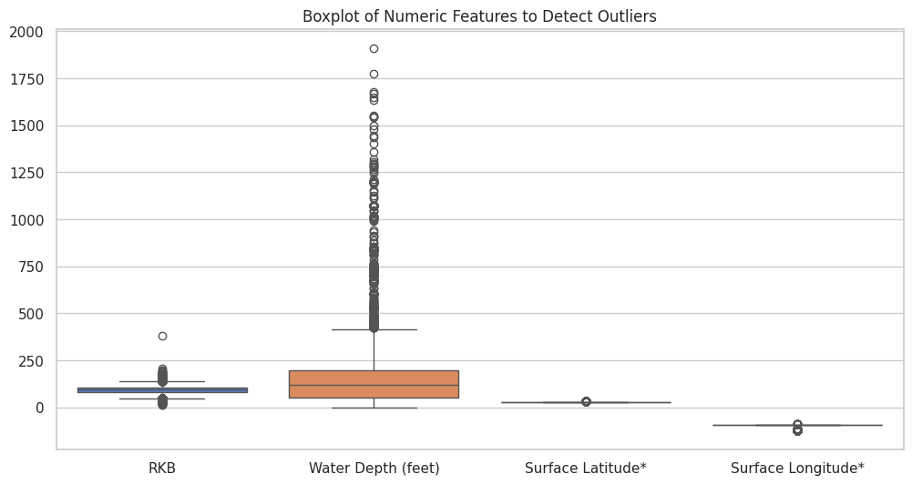

```python
plt.figure(figsize=(12, 6))
sns.boxplot(data=df_Gas_Oil[['RKB', 'Water Depth (feet)', 'Surface Latitude*', 'Surface Longitude*']])
plt.title("Boxplot of Numeric Features to Detect Outliers")
plt.show()
```

## Observations

# B.) Data Wrangling

### Cleaning Data

```python
if "#" in df_Gas_Oil.columns:
    df_Gas_Oil.drop(columns=["#"], inplace=True)
    print("Dropped column '#' (100% missing).")
```

```
Dropped column '#' (100% missing).
```

```python
cols_with_stars = [
    "BH Total MD (feet)",
    "True Vertical Depth (feet)",
    "TVD Subsea (feet)",
    "Bottom Latitude*",
    "Bottom Longitude*",
    "KOP"
]
```

```python
for col in cols_with_stars:
    if col in df_Gas_Oil.columns:
        df_Gas_Oil[col] = df_Gas_Oil[col].replace("*****", np.nan)
```

```python
for col in cols_with_stars:
    if col in df_Gas_Oil.columns:
        df_Gas_Oil[col] = pd.to_numeric(df_Gas_Oil[col], errors="coerce")
```

```python
date_cols = ["Spud Date", "Total Depth Date", "Status Date"]
for col in date_cols:
    if col in df_Gas_Oil.columns:
        df_Gas_Oil[col] = pd.to_datetime(df_Gas_Oil[col], errors="coerce")
```

```python
df_Gas_Oil.dtypes
```

|  | 0 |
| --- | --- |
| API Well Number | int64 |
| Well Name | object |
| Well Name Suffix | object |
| Bottom Lease Number | object |
| Bottom Area | object |
| Bottom Block | object |
| Region | object |
| Company Name | object |
| Spud Date | datetime64[ns] |
| BH Total MD (feet) | float64 |
| True Vertical Depth (feet) | float64 |
| TVD Subsea (feet) | float64 |
| RKB | float64 |
| KOP | float64 |
| Total Depth Date | datetime64[ns] |
| Status Date | datetime64[ns] |
| Type Code | object |
| Status Code | object |
| Casing Cut Code | object |
| Water Depth (feet) | float64 |
| Underwater Comp Stub | object |
| Surface Lease Number | object |
| Surface Latitude* | float64 |
| Surface Longitude* | float64 |
| Bottom Latitude* | float64 |
| Bottom Longitude* | float64 |

**dtype:** object

## Observation

- The cleaning phase removed unnecessary or empty columns, including the redundant **"#"** field.
- Placeholder values like **"*****"** were identified as invalid and converted into proper missing values.
- Several columns originally stored as text were corrected to their true formats, such as converting **Spud Date**, **Total Depth Date**, and **Status Date** into datetime objects.
- Numeric fields that were incorrectly typed as strings were also fixed for accurate computation.
- After these transformations, all columns had **consistent, analysis-ready data types**, setting a clean foundation for preprocessing and modeling.

```python
missing_values = df_Gas_Oil.isnull().sum().sort_values(ascending=False)
print("Missing values per column:\n", missing_values.head(15))
```

```
Missing values per column:
 KOP                           14589
Casing Cut Code                 767
Total Depth Date                366
Spud Date                       360
Bottom Longitude*               202
Bottom Latitude*                202
True Vertical Depth (feet)      180
BH Total MD (feet)              179
Status Date                     130
TVD Subsea (feet)               100
RKB                              87
Water Depth (feet)               51
Surface Longitude*                1
Surface Latitude*                 1
Bottom Lease Number               0
dtype: int64
```

### Handling Missing Values

```python
missing_percent = (df_Gas_Oil.isnull().sum() / len(df_Gas_Oil)) * 100
missing_summary = pd.DataFrame({
    "Missing Count": df_Gas_Oil.isnull().sum(),
    "Missing %": missing_percent
}).sort_values(by="Missing %", ascending=False)
```

```python
print("Missing Value Summary (%):")
display(missing_summary)
```

```
Missing Value Summary (%):
```

|  | Missing Count | Missing % |
| --- | --- | --- |
| KOP | 14589 | 72.945 |
| Casing Cut Code | 767 | 3.835 |
| Total Depth Date | 366 | 1.830 |
| Spud Date | 360 | 1.800 |
| Bottom Longitude* | 202 | 1.010 |
| Bottom Latitude* | 202 | 1.010 |
| True Vertical Depth (feet) | 180 | 0.900 |
| BH Total MD (feet) | 179 | 0.895 |
| Status Date | 130 | 0.650 |
| TVD Subsea (feet) | 100 | 0.500 |
| RKB | 87 | 0.435 |
| Water Depth (feet) | 51 | 0.255 |
| Surface Longitude* | 1 | 0.005 |
| Surface Latitude* | 1 | 0.005 |
| Bottom Lease Number | 0 | 0.000 |
| Well Name Suffix | 0 | 0.000 |
| API Well Number | 0 | 0.000 |
| Well Name | 0 | 0.000 |
| Region | 0 | 0.000 |
| Company Name | 0 | 0.000 |
| Bottom Area | 0 | 0.000 |
| Bottom Block | 0 | 0.000 |
| Status Code | 0 | 0.000 |
| Type Code | 0 | 0.000 |
| Surface Lease Number | 0 | 0.000 |
| Underwater Comp Stub | 0 | 0.000 |

```python
df_Gas_Oil.drop(columns=["KOP"], inplace=True)
print("\nDropped 'KOP' due to excessive missing values (~73%).")
```

```
Dropped 'KOP' due to excessive missing values (~73%).
```

```python
df_Gas_Oil.dropna(subset=["Surface Latitude*","Surface Longitude*"], inplace=True)
```

```python
for col in ["BH Total MD (feet)", "True Vertical Depth (feet)", "TVD Subsea (feet)", "RKB", "Water Depth (feet)"]:
    if df_Gas_Oil[col].isnull().sum() > 0:
        median_value = df_Gas_Oil[col].median()
        df_Gas_Oil[col].fillna(median_value, inplace=True)
```

```python
print("\nRemaining missing values after cleaning:")
print(df_Gas_Oil.isnull().sum().sort_values(ascending=False).head(10))
```

```
Remaining missing values after cleaning:
Casing Cut Code        767
Total Depth Date       365
Spud Date              359
Bottom Latitude*       201
Bottom Longitude*      201
Status Date            130
API Well Number          0
Bottom Lease Number      0
Well Name                0
Company Name             0
dtype: int64
```

## Observation

- Several columns contained partial missing values, mainly involving **dates, coordinates, and operational codes**.
- The **KOP column** was dropped due to its high missingness (~73%), making it unsuitable for meaningful analysis.
- Numeric fields with minimal gaps (<1%)—such as BH Total MD, True Vertical Depth, TVD Subsea, RKB, and Water Depth—were **median-imputed** to preserve distribution symmetry.
- Some columns intentionally retained missing values because they carry **operational meaning**, not data errors:
  - Missing **date fields** often indicate wells still drilling or awaiting updates.
  - Missing **bottom-hole coordinates** reflect wells where the final survey wasn’t recorded.
  - Missing **Casing Cut Codes** likely represent cases where the operation wasn’t applicable.
- Keeping these meaningful nulls prevents data bias and helps preserve real-world drilling patterns.
- This selective treatment ensures the dataset remains **authentic, complete, and suitable for advanced analysis and modeling**.

### Transforming Variables

```python
df_Gas_Oil["Surface Latitude*"]  = df_Gas_Oil["Surface Latitude*"].round(4)
```

```python
df_Gas_Oil["Surface Longitude*"] = df_Gas_Oil["Surface Longitude*"].round(4)
```

```python
df_Gas_Oil["Bottom Latitude*"]   = df_Gas_Oil["Bottom Latitude*"].round(4)
```

```python
df_Gas_Oil["Bottom Longitude*"]  = df_Gas_Oil["Bottom Longitude*"].round(4)
```

```python
if "Region" in df_Gas_Oil.columns:
    df_Gas_Oil["Region"] = df_Gas_Oil["Region"].str.title()
```

```python
df_Gas_Oil["Company Name"] = df_Gas_Oil["Company Name"].str.strip()
```

```python
cat_cols = ["Type Code", "Status Code", "Casing Cut Code", "Underwater Comp Stub"]
for col in cat_cols:
    if col in df_Gas_Oil.columns:
        df_Gas_Oil[col] = df_Gas_Oil[col].str.upper().str.strip()
```

```python
df_Gas_Oil[["Region", "Company Name", "Surface Latitude*",
            "Surface Longitude*", "Bottom Latitude*", "Bottom Longitude*"]].head()
```

|  | Region | Company Name | Surface Latitude* | Surface Longitude* | Bottom Latitude* | Bottom Longitude* |
| --- | --- | --- | --- | --- | --- | --- |
| 0 | Gulf Of America | Exxon Mobil Corporation | 30.1885 | -87.9586 | 30.1888 | -87.9585 |
| 1 | Gulf Of America | Exxon Mobil Corporation | 30.1815 | -87.9415 | 30.1805 | -87.9281 |
| 2 | Gulf Of America | Exxon Mobil Corporation | 30.1884 | -87.9539 | 30.1838 | -87.9582 |
| 3 | Gulf Of America | Exxon Mobil Corporation | 30.1959 | -87.9773 | 30.1959 | -87.9773 |
| 4 | Pacific | Pacific Operators Offshore, LLC | 34.3382 | -119.5366 | 34.3384 | -119.5370 |

```python
print(df_Gas_Oil["Region"].unique())
```

```
['Gulf Of America' 'Pacific']
```

```python
print(df_Gas_Oil["Type Code"].unique())
```

```
['E' 'D' 'R' 'S' 'C']
```

```python
print(df_Gas_Oil["Status Code"].unique())
```

```
['COM' 'PA' 'ST' 'TA' 'CNL' 'DSI' 'APD' 'AST' 'DRL']
```

## Observations

- Transformations focused on improving consistency while keeping original meaning intact.
- Coordinate fields (Surface & Bottom Lat/Long) were rounded to **four decimal places**, maintaining ~11m precision while improving readability.
- Region names were standardized to **title case**, ensuring consistent grouping in visualizations.
- Company Name entries were cleaned by removing extra spaces to avoid duplicates arising from formatting inconsistencies.
- Categorical codes (Type Code, Status Code, Casing Cut Code) were **uppercased and stripped of whitespace** for uniform classification.
- These transformations reduced redundancy, improved data structure, and ensured reliable grouping, filtering, and comparison.
- The dataset is now standardized, clean, and ready for accurate visualization and further analysis.

### Engineering New Variables

```python
df_Gas_Oil["Drilling_Duration_days"] = (
    df_Gas_Oil["Total Depth Date"] - df_Gas_Oil["Spud Date"]
).dt.days
```

```python
df_Gas_Oil["Depth_Difference"] = (
    df_Gas_Oil["BH Total MD (feet)"] - df_Gas_Oil["True Vertical Depth (feet)"]
)
```

```python
df_Gas_Oil["Deepwater_Flag"] = df_Gas_Oil["Water Depth (feet)"] > 1000
```

```python
df_Gas_Oil[["Drilling_Duration_days", "Depth_Difference", "Deepwater_Flag"]].head()
```

|  | Drilling_Duration_days | Depth_Difference | Deepwater_Flag |
| --- | --- | --- | --- |
| 0 | 167.0 | 3.0 | False |
| 1 | 152.0 | 801.0 | False |
| 2 | 125.0 | 407.0 | False |
| 3 | 126.0 | 1.0 | False |
| 4 | 7.0 | 4.0 | False |

```python
df_Gas_Oil[["Drilling_Duration_days", "Depth_Difference", "Water Depth (feet)"]].describe()
```

|  | Drilling_Duration_days | Depth_Difference | Water Depth (feet) |
| --- | --- | --- | --- |
| count | 19634.000000 | 19999.000000 | 19999.000000 |
| mean | 30.565753 | 818.716436 | 151.623181 |
| std | 83.327229 | 1165.326780 | 160.186877 |
| min | 0.000000 | 0.000000 | 0.000000 |
| 25% | 11.000000 | 11.000000 | 52.000000 |
| 50% | 19.000000 | 440.000000 | 119.000000 |
| 75% | 34.000000 | 1162.000000 | 197.000000 |
| max | 5514.000000 | 30227.000000 | 1911.000000 |

```python
df_Gas_Oil["Deepwater_Flag"].value_counts()
```

| Deepwater_Flag | count |
| --- | --- |
| False | 19791 |
| True | 208 |

**dtype:** int64

## Observation

- New engineered features were created to enhance analytical depth and operational insight.
- **Drilling_Duration_days** measures the time from *Spud Date* to *Total Depth Date*, enabling evaluation of drilling efficiency and identification of unusually long or short projects.
- **Depth_Difference** (BH Total MD − True Vertical Depth) quantifies well deviation, helping distinguish vertical wells from directional or horizontal drilling.
- **Deepwater_Flag** marks wells drilled in **>1000 ft** of water, making it easy to compare deepwater vs. shallow-water operations.
- These engineered variables provide richer context, support performance benchmarking, and enable clearer visualization of drilling behavior and trends.

### Handling Outliers

```python
numeric_cols = ["RKB", "Water Depth (feet)", "Drilling_Duration_days", "Depth_Difference"]
```

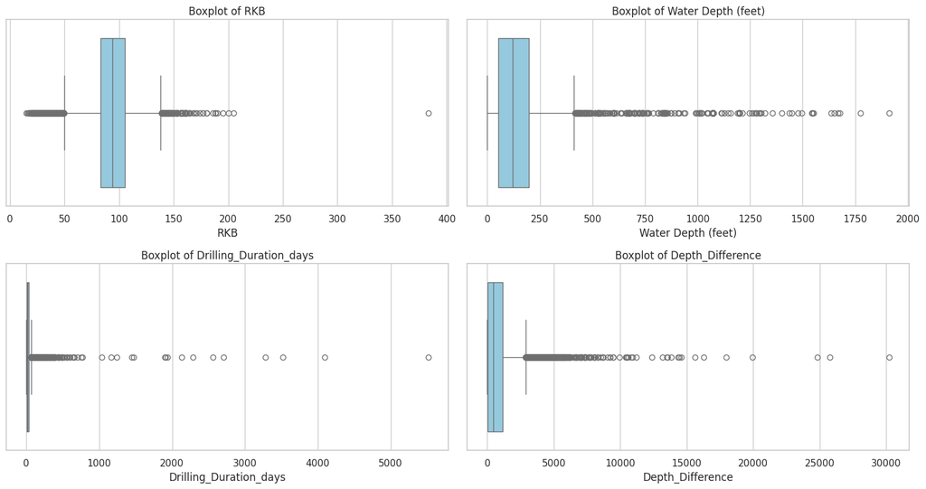

```python
plt.figure(figsize=(15, 8))
for i, col in enumerate(numeric_cols, 1):
    plt.subplot(2, 2, i)
    sns.boxplot(x=df_Gas_Oil[col], color="skyblue")
    plt.title(f"Boxplot of {col}")
plt.tight_layout()
plt.show()
```

```python
outlier_summary = {}
for col in numeric_cols:
    z = np.abs(stats.zscore(df_Gas_Oil[col].dropna()))
    outlier_summary[col] = (z > 3).sum()
```

```python
print("Number of Outliers (|z| > 3) per Variable:")
for col, count in outlier_summary.items():
    print(f"{col}: {count}")
```

```
Number of Outliers (|z| > 3) per Variable:
RKB: 73
Water Depth (feet): 504
Drilling_Duration_days: 80
Depth_Difference: 295
```

### Handling dimensionality reduction

```python
numeric_df = df_Gas_Oil.select_dtypes(include=["float64", "int64"])
```

```python
corr_matrix = numeric_df.corr()
```

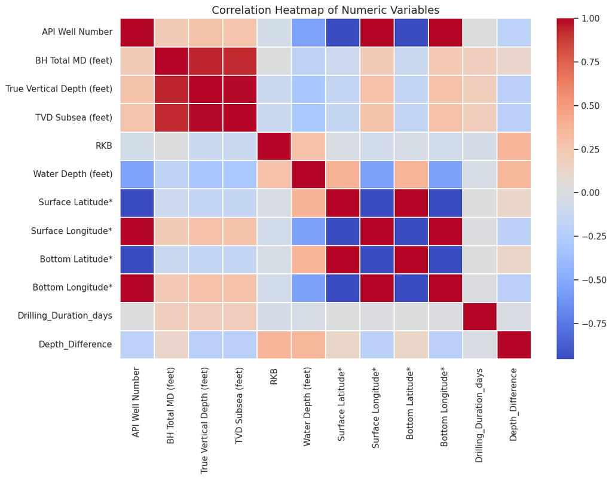

```python
# Plot correlation heatmap
plt.figure(figsize=(12, 8))
sns.heatmap(corr_matrix, annot=False, cmap="coolwarm", linewidths=0.3)
plt.title("Correlation Heatmap of Numeric Variables", fontsize=14)
plt.show()
```

```python
high_corr_pairs = (
    corr_matrix.where(np.triu(np.ones(corr_matrix.shape), k=1).astype(bool))
    .stack()
    .reset_index()
)
```

```python
high_corr_pairs.columns = ["Variable 1", "Variable 2", "Correlation"]
```

```python
high_corr_pairs = high_corr_pairs[np.abs(high_corr_pairs["Correlation"]) > 0.85]
```

```python
display(high_corr_pairs)
```

|  | Variable 1 | Variable 2 | Correlation |
| --- | --- | --- | --- |
| 5 | API Well Number | Surface Latitude* | -0.952205 |
| 6 | API Well Number | Surface Longitude* | 0.993240 |
| 7 | API Well Number | Bottom Latitude* | -0.951509 |
| 8 | API Well Number | Bottom Longitude* | 0.993107 |
| 11 | BH Total MD (feet) | True Vertical Depth (feet) | 0.945161 |
| 12 | BH Total MD (feet) | TVD Subsea (feet) | 0.930853 |
| 21 | True Vertical Depth (feet) | TVD Subsea (feet) | 0.985708 |
| 51 | Surface Latitude* | Surface Longitude* | -0.954918 |
| 52 | Surface Latitude* | Bottom Latitude* | 0.999992 |
| 53 | Surface Latitude* | Bottom Longitude* | -0.954249 |
| 56 | Surface Longitude* | Bottom Latitude* | -0.954213 |
| 57 | Surface Longitude* | Bottom Longitude* | 0.999999 |
| 60 | Bottom Latitude* | Bottom Longitude* | -0.954210 |

## Observations

- The correlation matrix revealed strong multicollinearity among several numeric features.
- **BH Total MD**, **True Vertical Depth**, and **TVD Subsea** show extremely high correlations (r > 0.93), indicating they represent similar depth-related information.
- Coordinate pairs—Surface and Bottom Latitude/Longitude—are highly interdependent (r ≈ ±0.95–1.00), expected due to geographic alignment of well paths.
- The **API Well Number** is also strongly correlated with location variables because its structured format encodes geographic blocks.
- Independent variables such as **RKB**, **Water Depth**, **Drilling_Duration_days**, and **Depth_Difference** capture different operational characteristics.
- While multicollinearity suggests certain features are redundant for modeling, all were retained for exploratory analysis to preserve spatial and operational interpretability.
- Future modeling could benefit from **feature reduction** (e.g., PCA or selective removal) to avoid redundant depth and coordinate variables.

```python
df_Gas_Oil.head(10)
```

|  | API Well Number | Well Name | Well Name Suffix | Bottom Lease Number | Bottom Area | Bottom Block | Region | Company Name | Spud Date | BH Total MD (feet) | ... | Water Depth (feet) | Underwater Comp Stub | Surface Lease Number | Surface Latitude* | Surface Longitude* | Bottom Latitude* | Bottom Longitude* | Drilling_Duration_days | Depth_Difference | Deepwater_Flag |
| --- | --- | --- | --- | --- | --- | --- | --- | --- | --- | --- | --- | --- | --- | --- | --- | --- | --- | --- | --- | --- | --- |
| 0 | 12032016500 | 001 | ST00BP00 | S00538 | MO | 827 | Gulf Of America | Exxon Mobil Corporation | 1984-09-24 | 21678.0 | ... | 45.0 | N | S00538 | 30.1885 | -87.9586 | 30.1888 | -87.9585 | 167.0 | 3.0 | False |
| 1 | 12032027100 | 001 | ST00BP00 | S00539 | MO | 828 | Gulf Of America | Exxon Mobil Corporation | 1991-11-27 | 22646.0 | ... | 46.0 | N | S00538 | 30.1815 | -87.9415 | 30.1805 | -87.9281 | 152.0 | 801.0 | False |
| 2 | 12032029300 | 002 | ST00BP00 | S00538 | MO | 827 | Gulf Of America | Exxon Mobil Corporation | 2002-03-28 | 22160.0 | ... | 45.0 | N | S00538 | 30.1884 | -87.9539 | 30.1838 | -87.9582 | 125.0 | 407.0 | False |
| 3 | 12032030900 | 003 | ST00BP00 | S00538 | MO | 827 | Gulf Of America | Exxon Mobil Corporation | 2009-01-02 | 21711.0 | ... | 45.0 | N | S00538 | 30.1959 | -87.9773 | 30.1959 | -87.9773 | 126.0 | 1.0 | False |
| 4 | 43110009100 | 002 | ST00BP00 | P00166 | LA | 6660 | Pacific | Pacific Operators Offshore, LLC | 1967-03-12 | 5000.0 | ... | 150.0 | N | P00166 | 34.3382 | -119.5366 | 34.3384 | -119.5370 | 7.0 | 4.0 | False |
| 5 | 43110009200 | 003 | ST00BP00 | P00166 | LA | 6660 | Pacific | Pacific Operators Offshore, LLC | 1967-03-03 | 5000.0 | ... | 165.0 | N | P00166 | 34.3332 | -119.5548 | 34.3332 | -119.5558 | 7.0 | 13.0 | False |
| 6 | 43110009300 | 005 | ST00BP00 | P00166 | LA | 6660 | Pacific | Pacific Operators Offshore, LLC | 1967-03-22 | 4940.0 | ... | 145.0 | N | P00166 | 34.3369 | -119.5319 | 34.3372 | -119.5327 | 9.0 | 10.0 | False |
| 7 | 43110009400 | 006 | ST00BP00 | P00166 | LA | 6660 | Pacific | Pacific Operators Offshore, LLC | 1967-04-03 | 5939.0 | ... | 156.0 | N | P00166 | 34.3367 | -119.5477 | 34.3361 | -119.5482 | 12.0 | 8.0 | False |
| 8 | 43110016500 | 001 | ST00BP00 | P00166 | LA | 6660 | Pacific | Pacific Operators Offshore, LLC | 1967-02-18 | 6121.0 | ... | 155.0 | N | P00166 | 34.3390 | -119.5550 | 34.3377 | -119.5542 | 11.0 | 42.0 | False |
| 9 | 43110016600 | 004 | ST00BP00 | P00166 | LA | 6660 | Pacific | Pacific Operators Offshore, LLC | 1967-05-10 | 14229.0 | ... | 115.0 | N | P00166 | 34.3363 | -119.5525 | 34.3339 | -119.5510 | 114.0 | 52.0 | False |

10 rows × 28 columns

```python
df_Gas_Oil.shape
```

```
(19999, 28)
```

```python
df_Gas_Oil.info()
```

```
<class 'pandas.core.frame.DataFrame'>
Index: 19999 entries, 0 to 19999
Data columns (total 28 columns):
 #   Column                      Non-Null Count  Dtype
---  ------                      --------------  -----
 0   API Well Number             19999 non-null  int64
 1   Well Name                   19999 non-null  object
 2   Well Name Suffix            19999 non-null  object
 3   Bottom Lease Number         19999 non-null  object
 4   Bottom Area                 19999 non-null  object
 5   Bottom Block                19999 non-null  object
 6   Region                      19999 non-null  object
 7   Company Name                19999 non-null  object
 8   Spud Date                   19640 non-null  datetime64[ns]
 9   BH Total MD (feet)          19999 non-null  float64
```

[output cut: 20 more lines]

```python
df_Gas_Oil.describe()

df_Gas_Oil.to_csv('cleaned_bsee_well_data.csv', index=False)

# Download the file (Colab)
from google.colab import files
files.download('cleaned_bsee_well_data.csv')
```

## C.) EDA Summary

1. The dataset contains **20,000 wells and 27 variables** covering geological, operational, and spatial details.
2. Each row represents a unique well with attributes like depth, region, company, and coordinates.
3. Variable types include **numeric, categorical, and datetime**, supporting statistical and trend analyses.
4. Initial checks confirmed consistent dimensions and realistic data types matching real-world drilling operations.
5. Depth-related fields showed high variability, representing both shallow and deep wells.
6. Average **water depth ≈ 150 ft**, indicating predominantly shallow-water operations with some deepwater wells.
7. Latitude and longitude values were tightly clustered, confirming most wells are in the **Gulf of America** region.
8. Categorical analysis showed major operators such as **Apache**, **Chevron**, and **Talos ERT**, with many wells marked **Type D (Development)** and **Status PA (Plugged & Abandoned)**.
9. Data cleaning included removing redundant columns, converting placeholder “*****” entries to nulls, and standardizing formats.
10. Date columns (Spud Date, Total Depth Date, Status Date) were successfully converted to datetime.
11. Missing value analysis showed low missingness overall, except the **KOP column**, which was dropped due to ~73% null values.
12. Numeric missing values were imputed using the **median**, while meaningful nulls in dates and coordinates were preserved for operational interpretation.
13. Transformations standardized categorical fields, trimmed text, and rounded coordinate values to four decimal places.
14. Engineered features—**Drilling_Duration_days**, **Depth_Difference**, **Deepwater_Flag**—added valuable operational insight.
15. Outliers were identified in water depth, drilling duration, and deviation metrics but retained because they represent valid domain behavior.
16. Correlation analysis revealed strong multicollinearity among depth and coordinate variables (r > 0.93 and r ≈ ±0.95–1.00).
17. No dimensionality reduction was applied to maintain interpretability during exploratory analysis.
18. Overall, the dataset is **clean, consistent, and ready for comprehensive univariate, bivariate, and multivariate analysis**.

# DATA VISUALIZATION

### Basic Health Check (missingness & zero-variance)

```python
# Ensure we are working with the processed dataframe
df_viz = df_Gas_Oil.copy()
df_viz.head()
```

|  | API Well Number | Well Name | Well Name Suffix | Bottom Lease Number | Bottom Area | Bottom Block | Region | Company Name | Spud Date | BH Total MD (feet) | ... | Water Depth (feet) | Underwater Comp Stub | Surface Lease Number | Surface Latitude* | Surface Longitude* | Bottom Latitude* | Bottom Longitude* | Drilling_Duration_days | Depth_Difference | Deepwater_Flag |
| --- | --- | --- | --- | --- | --- | --- | --- | --- | --- | --- | --- | --- | --- | --- | --- | --- | --- | --- | --- | --- | --- |
| 0 | 12032016500 | 001 | ST00BP00 | S00538 | MO | 827 | Gulf Of America | Exxon Mobil Corporation | 1984-09-24 | 21678.0 | ... | 45.0 | N | S00538 | 30.1885 | -87.9586 | 30.1888 | -87.9585 | 167.0 | 3.0 | False |
| 1 | 12032027100 | 001 | ST00BP00 | S00539 | MO | 828 | Gulf Of America | Exxon Mobil Corporation | 1991-11-27 | 22646.0 | ... | 46.0 | N | S00538 | 30.1815 | -87.9415 | 30.1805 | -87.9281 | 152.0 | 801.0 | False |
| 2 | 12032029300 | 002 | ST00BP00 | S00538 | MO | 827 | Gulf Of America | Exxon Mobil Corporation | 2002-03-28 | 22160.0 | ... | 45.0 | N | S00538 | 30.1884 | -87.9539 | 30.1838 | -87.9582 | 125.0 | 407.0 | False |
| 3 | 12032030900 | 003 | ST00BP00 | S00538 | MO | 827 | Gulf Of America | Exxon Mobil Corporation | 2009-01-02 | 21711.0 | ... | 45.0 | N | S00538 | 30.1959 | -87.9773 | 30.1959 | -87.9773 | 126.0 | 1.0 | False |
| 4 | 43110009100 | 002 | ST00BP00 | P00166 | LA | 6660 | Pacific | Pacific Operators Offshore, LLC | 1967-03-12 | 5000.0 | ... | 150.0 | N | P00166 | 34.3382 | -119.5366 | 34.3384 | -119.5370 | 7.0 | 4.0 | False |

5 rows × 28 columns

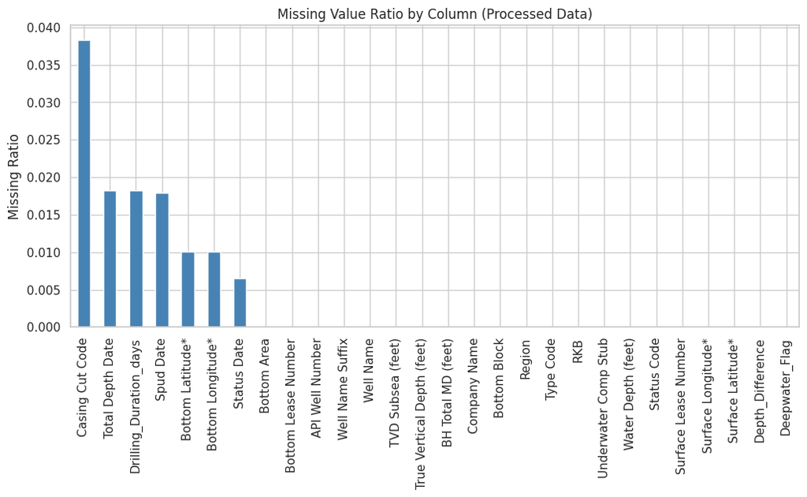

```python
import warnings
warnings.filterwarnings("ignore")

missing = df_viz.isna().mean().sort_values(ascending=False)

plt.figure(figsize=(12,5))
missing.plot(kind='bar', color='steelblue')
plt.title('Missing Value Ratio by Column (Processed Data)')
plt.ylabel('Missing Ratio')
plt.xticks(rotation=90)
plt.show()
```

#### Univariate Analysis

A) Water Depth Distribution(histogram)

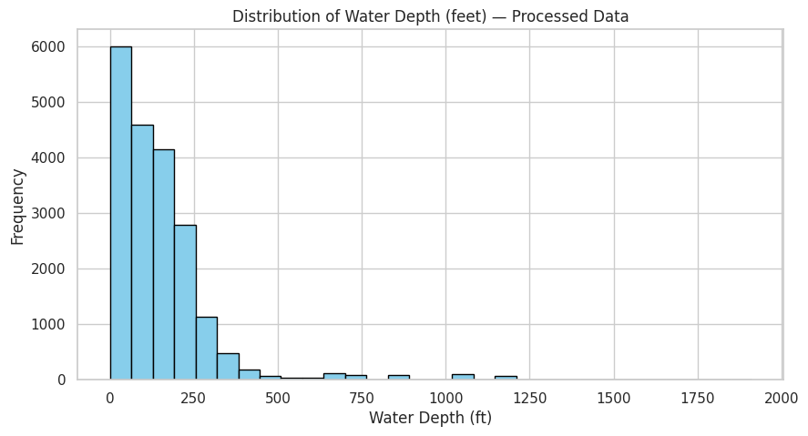

```python
plt.figure(figsize=(10,5))
plt.hist(df_viz['Water Depth (feet)'], bins=30, color='skyblue', edgecolor='black')
plt.title("Distribution of Water Depth (feet) — Processed Data")
plt.xlabel("Water Depth (ft)")
plt.ylabel("Frequency")
plt.show()
```

**Observation:**  
The Water Depth distribution is right-skewed, showing that most wells are located in shallow to mid-depth waters, typically under 400 feet. A smaller number of wells extend into deeper waters, forming a long tail. This reflects typical offshore drilling patterns where shallow shelf regions historically dominate activity.

Univariate Analysis  
B) Measured Depth (MD) Distribution

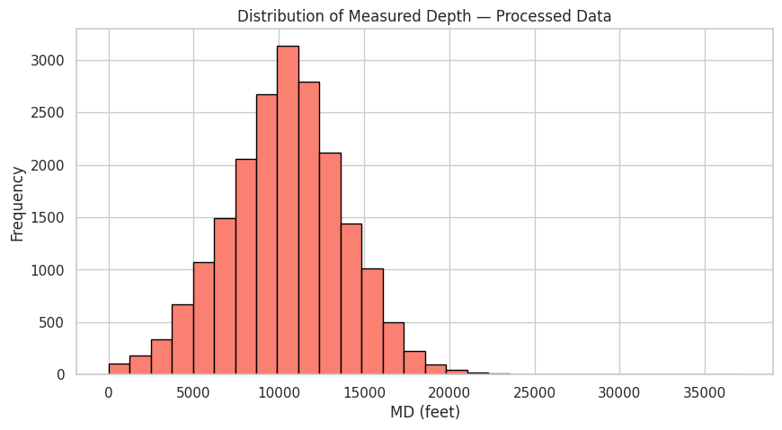

```python
plt.figure(figsize=(10,5))
plt.hist(df_viz['BH Total MD (feet)'], bins=30, color='salmon', edgecolor='black')
plt.title("Distribution of Measured Depth — Processed Data")
plt.xlabel("MD (feet)")
plt.ylabel("Frequency")
plt.show()
```

**Observation:**  
Measured Depth shows a broad spread, with many wells drilled between 8,000 and 12,000 feet. The distribution suggests variation in drilling objectives and geologic targets. A few wells reach significantly deeper depths, indicating more complex or extended-reach drilling programs.

Univariate Analysis  
C) Wells by Region(Bar Plot)

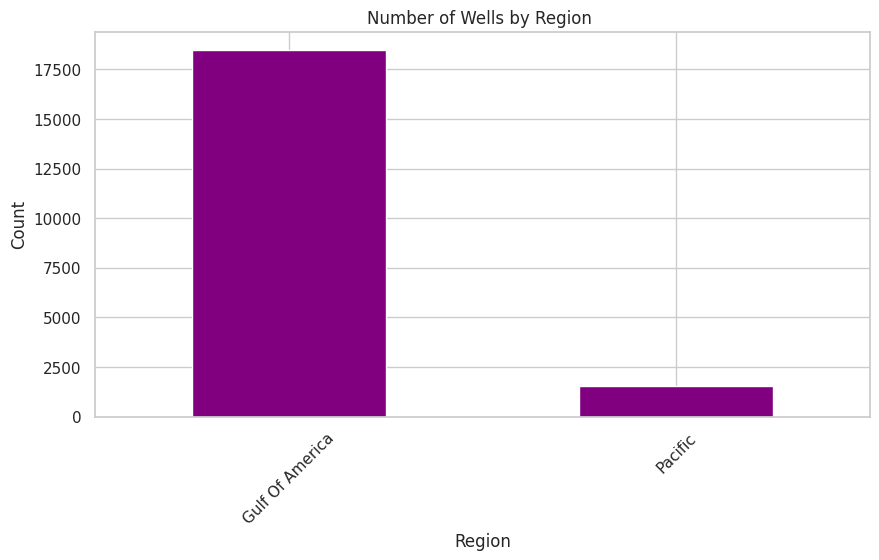

```python
plt.figure(figsize=(10,5))
df_viz['Region'].value_counts().plot(kind='bar', color='purple')
plt.title("Number of Wells by Region ")
plt.xlabel("Region")
plt.ylabel("Count")
plt.xticks(rotation=45)
plt.show()
```

**Observation:**  
The region-wise plot shows that one region—largely the Gulf area—dominates well activity, holding the majority of drilling operations. This illustrates a strong geographic concentration of offshore exploration and production, driven by infrastructure, reservoir availability, and long-established development trends.

#### Bivariate

A) MD vs TVD (Scatter Plot)

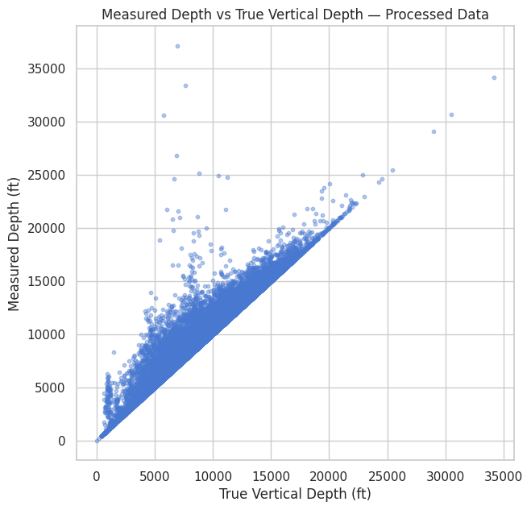

```python
plt.figure(figsize=(7,7))
plt.scatter(df_viz['True Vertical Depth (feet)'],
            df_viz['BH Total MD (feet)'],
            alpha=0.4, s=10)

plt.title("Measured Depth vs True Vertical Depth — Processed Data")
plt.xlabel("True Vertical Depth (ft)")
plt.ylabel("Measured Depth (ft)")
plt.show()
```

#### Bivariate

B) Median Water Depth by Status Code

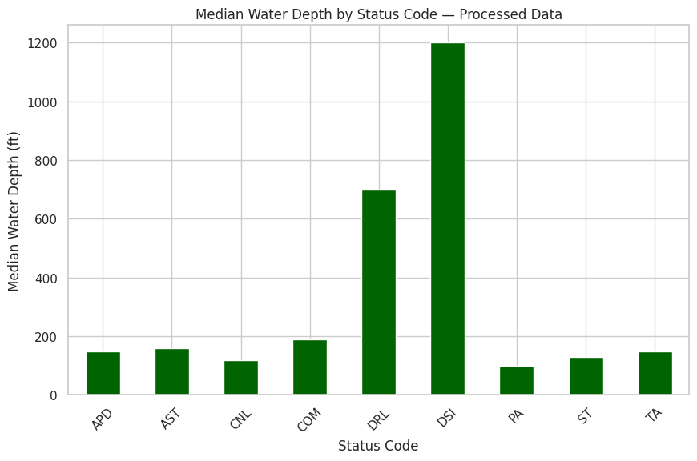

```python
plt.figure(figsize=(10,6))
df_viz.groupby('Status Code')['Water Depth (feet)'].median().plot(kind='bar', color='darkgreen')
plt.title('Median Water Depth by Status Code — Processed Data')
plt.xlabel('Status Code')
plt.ylabel('Median Water Depth (ft)')
plt.xticks(rotation=45)
plt.show()
```

**Observation:**  
The median water depth for each status code shows that well statuses differ based on water depth. Plugged and abandoned wells tend to be in shallower waters, while active or completed wells appear in deeper areas. This pattern reflects how operational stages vary across water depth categories. .

#### Multivariate

A) Correlation Heatmap

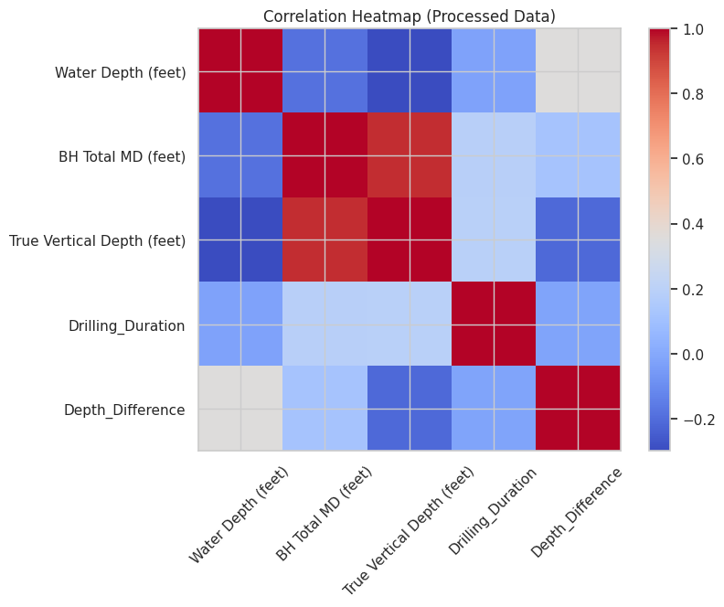

```python
# Create Drilling_Duration if missing
if 'Drilling_Duration' not in df_viz.columns:
    df_viz['Drilling_Duration'] = (df_viz['Total Depth Date'] - df_viz['Spud Date']).dt.days

# Create Depth_Difference if missing
if 'Depth_Difference' not in df_viz.columns:
    df_viz['Depth_Difference'] = df_viz['BH Total MD (feet)'] - df_viz['True Vertical Depth (feet)']

num_cols = ['Water Depth (feet)',
            'BH Total MD (feet)',
            'True Vertical Depth (feet)',
            'Drilling_Duration',
            'Depth_Difference']


corr = df_viz[num_cols].corr()

plt.figure(figsize=(8,6))
plt.imshow(corr, cmap='coolwarm', interpolation='nearest')
plt.colorbar()
plt.xticks(range(len(num_cols)), num_cols, rotation=45)
plt.yticks(range(len(num_cols)), num_cols)
plt.title("Correlation Heatmap (Processed Data)")
plt.show()
```

**Observation:**  
The heatmap shows strong positive correlation between Measured Depth and True Vertical Depth, which is expected because deeper wells tend to require greater measured depths. Meanwhile, Water Depth has weak correlation with subsurface depth metrics, indicating that seabed depth and drilling depth operate independently of one another.

#### Multivariate

C) Pairplot

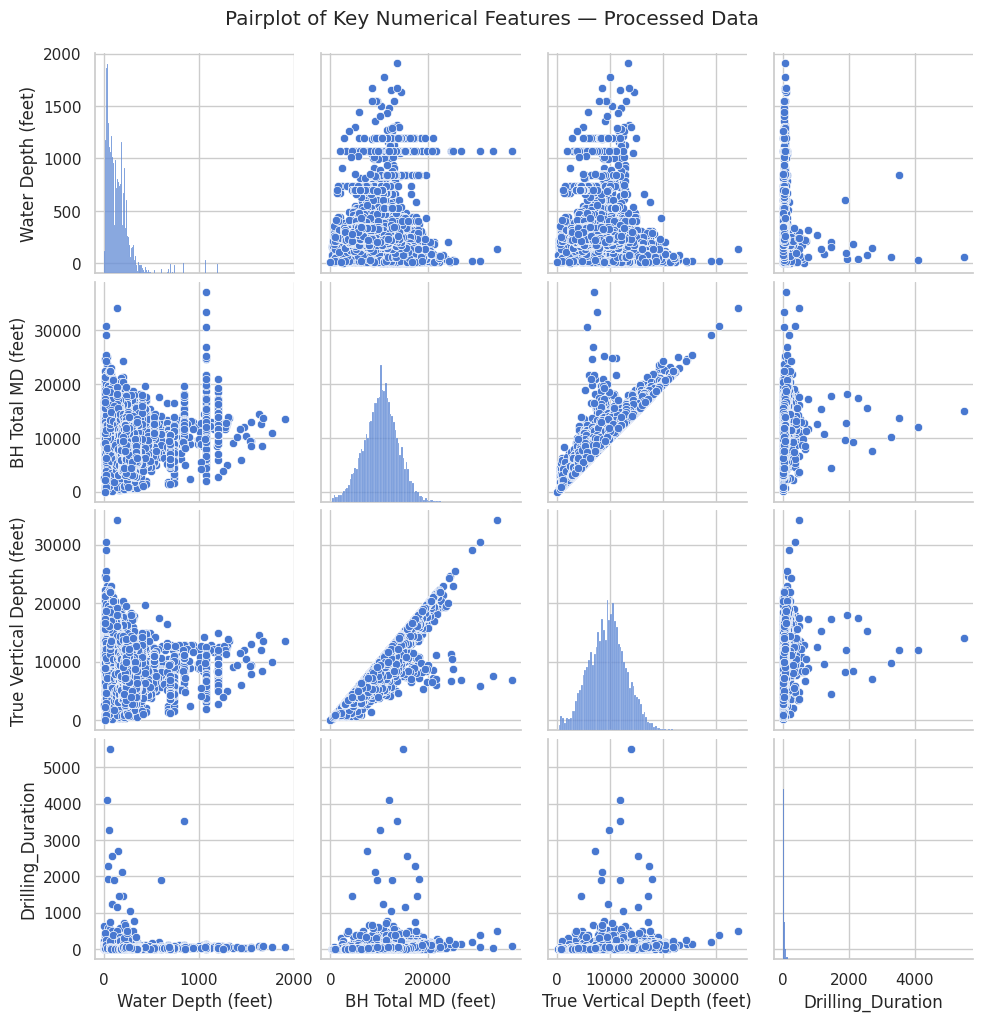

```python
sns.pairplot(df_viz[['Water Depth (feet)',
                     'BH Total MD (feet)',
                     'True Vertical Depth (feet)',
                     'Drilling_Duration']],
             diag_kind='hist')

plt.suptitle("Pairplot of Key Numerical Features — Processed Data", y=1.02)
plt.show()
```

**Observation:**  
The pairplot highlights core relationships between drilling metrics. True Vertical Depth and Measured Depth show a strong linear pattern, confirming consistent well geometry. Drilling Duration varies more widely and does not show strong dependency on depth values, suggesting that operational efficiency or geological complexity also plays a role.

# Data Mining Questions

## Question 1: What is the distribution of wells by region?

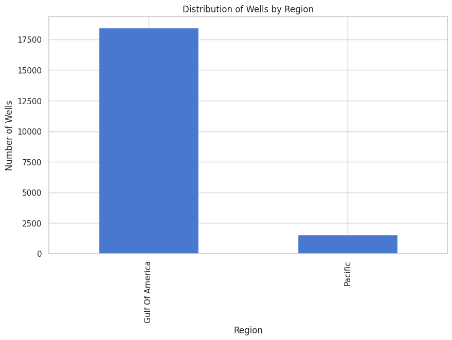

```python
import pandas as pd
import matplotlib.pyplot as plt

df = df_Gas_Oil.copy()
region_counts = df['Region'].value_counts()

plt.figure(figsize=(10, 6))
region_counts.plot(kind='bar')
plt.title('Distribution of Wells by Region')
plt.xlabel('Region')
plt.ylabel('Number of Wells')
plt.show()
```

### Observation:

The bar chart shows the number of wells in each region. This helps us understand the geographical distribution of drilling activities.

## Question 2: Who are the top 10 companies with the most wells?

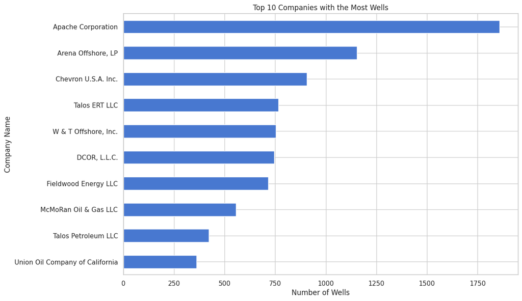

```python
top_10_companies = df['Company Name'].value_counts().nlargest(10)

plt.figure(figsize=(12, 8))
top_10_companies.plot(kind='barh')
plt.title('Top 10 Companies with the Most Wells')
plt.xlabel('Number of Wells')
plt.ylabel('Company Name')
plt.gca().invert_yaxis()
plt.show()
```

### Observation:

This horizontal bar chart displays the top 10 companies by the number of wells they operate. This provides insight into the major players in the offshore drilling industry.

## Question 3: What is the trend of well spudding over the years?

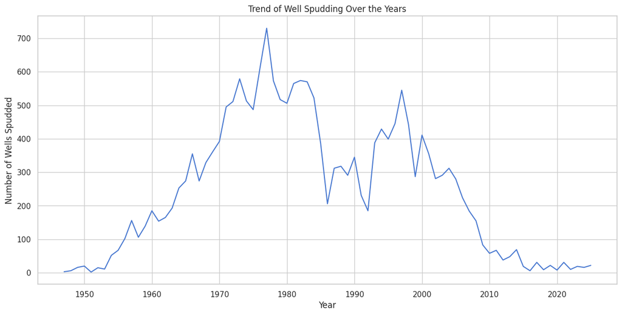

```python
df['Spud Date'] = pd.to_datetime(df['Spud Date'], errors='coerce')
spud_year_counts = df['Spud Date'].dt.year.value_counts().sort_index()

plt.figure(figsize=(15, 7))
spud_year_counts.plot(kind='line')
plt.title('Trend of Well Spudding Over the Years')
plt.xlabel('Year')
plt.ylabel('Number of Wells Spudded')
plt.grid(True)
plt.show()
```

### Observation:

The line chart illustrates the number of wells spudded each year. This helps to identify periods of high and low drilling activity, potentially correlating with economic or technological changes.

## Question 4: What is the relationship between 'BH Total MD (feet)' and 'True Vertical Depth (feet)'?

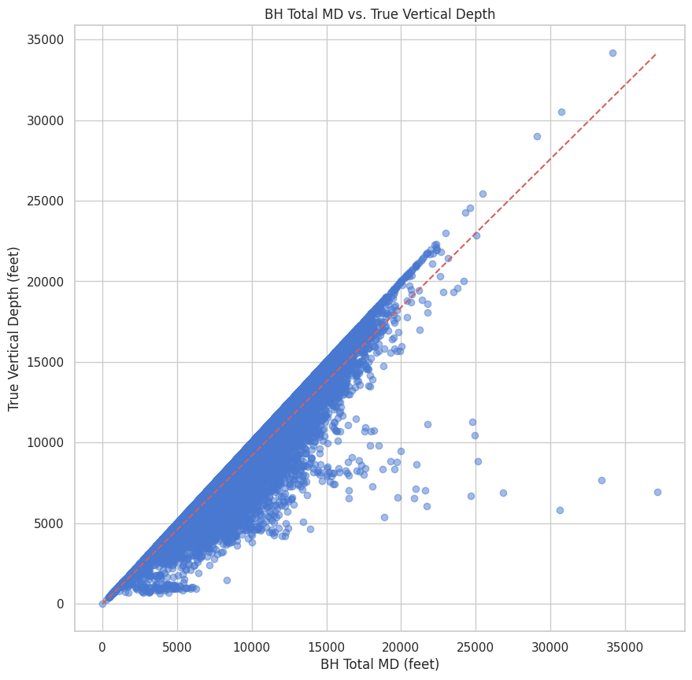

```python
df['BH Total MD (feet)'] = pd.to_numeric(df['BH Total MD (feet)'], errors='coerce')
df['True Vertical Depth (feet)'] = pd.to_numeric(df['True Vertical Depth (feet)'], errors='coerce')
df_cleaned = df.dropna(subset=['BH Total MD (feet)', 'True Vertical Depth (feet)'])
plt.figure(figsize=(10, 10))
plt.scatter(df_cleaned['BH Total MD (feet)'], df_cleaned['True Vertical Depth (feet)'], alpha=0.5)
plt.title('BH Total MD vs. True Vertical Depth')
plt.xlabel('BH Total MD (feet)')
plt.ylabel('True Vertical Depth (feet)')
plt.plot([0, df_cleaned['BH Total MD (feet)'].max()], [0, df_cleaned['True Vertical Depth (feet)'].max()], 'r--')
plt.show()
```

## Question 5: What is the distribution of water depth?

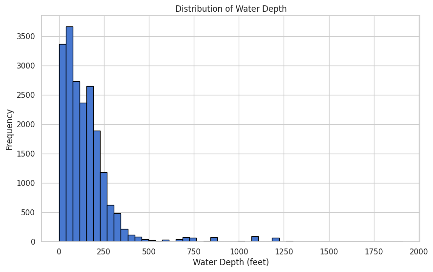

```python
plt.figure(figsize=(10, 6))
plt.hist(df['Water Depth (feet)'].dropna(), bins=50, edgecolor='black')
plt.title('Distribution of Water Depth')
plt.xlabel('Water Depth (feet)')
plt.ylabel('Frequency')
plt.show()
```

### Observation:

The histogram shows the frequency distribution of water depths for the wells. This helps to understand the environment in which these wells are drilled, whether they are predominantly in shallow or deep water.

## Question 6: What are the different well statuses and their counts?

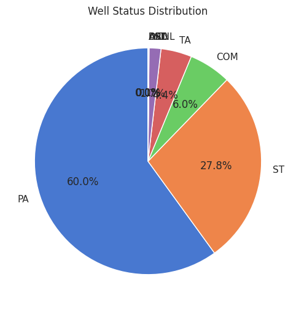

```python
status_counts = df['Status Code'].value_counts()

plt.figure(figsize=(10, 6))
status_counts.plot(kind='pie', autopct='%1.1f%%', startangle=90)
plt.title('Well Status Distribution')
plt.ylabel('')
plt.show()
```

### Observation:

The pie chart illustrates the proportion of wells in different statuses (e.g., 'COM' for completed, 'PA' for plugged and abandoned). This gives an overview of the operational state of the wells in the dataset.

## Question 7: What are the different well types and their counts?

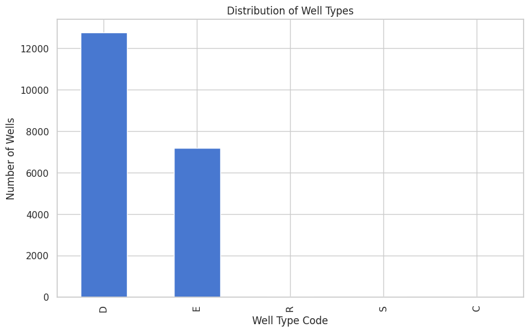

```python
type_counts = df['Type Code'].value_counts()

plt.figure(figsize=(10, 6))
type_counts.plot(kind='bar')
plt.title('Distribution of Well Types')
plt.xlabel('Well Type Code')
plt.ylabel('Number of Wells')
plt.show()
```

### Observation:

This bar chart shows the counts of different well types (e.g., 'E' for exploratory). This helps in understanding the primary purpose of the drilling activities (e.g., exploration vs. development).

## Question 8: What is the average 'True Vertical Depth (feet)' for each region?

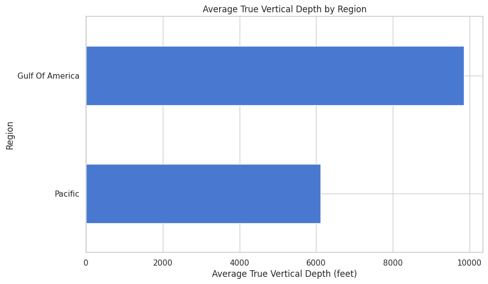

```python
avg_depth_by_region = df.groupby('Region')['True Vertical Depth (feet)'].mean().sort_values()

plt.figure(figsize=(10, 6))
avg_depth_by_region.plot(kind='barh')
plt.title('Average True Vertical Depth by Region')
plt.xlabel('Average True Vertical Depth (feet)')
plt.ylabel('Region')
plt.show()
```

### Observation:

This horizontal bar chart compares the average 'True Vertical Depth' of wells across different regions. This can indicate geological differences or varying exploration strategies among regions.

## Question 9: How does the 'Water Depth (feet)' vary by region?

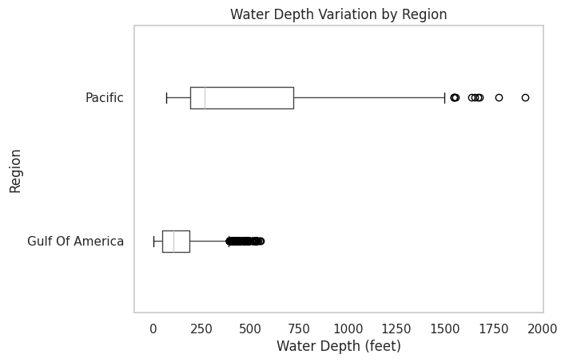

```python
plt.figure(figsize=(12, 8))
df.boxplot(column='Water Depth (feet)', by='Region', grid=False, vert=False)
plt.title('Water Depth Variation by Region')
plt.suptitle('')
plt.xlabel('Water Depth (feet)')
plt.ylabel('Region')
plt.show()
```

### Observation:

The box plot shows the distribution of 'Water Depth' for each region. This allows for a comparison of the range and median water depths across regions, highlighting which regions involve more deepwater drilling.

## Question 10: What is the deepest well drilled?

```python
deepest_well = df.loc[df['True Vertical Depth (feet)'].idxmax()]
print('Details of the deepest well:')
print(deepest_well[['API Well Number', 'Company Name', 'Region', 'True Vertical Depth (feet)']])
```

```
Details of the deepest well:
API Well Number                        177094150501
Company Name                  McMoRan Oil & Gas LLC
Region                              Gulf Of America
True Vertical Depth (feet)                  34162.0
Name: 18913, dtype: object
```

### Observation:

The code identifies and prints the details of the well with the maximum 'True Vertical Depth'. This provides a specific data point of interest, highlighting the extent of drilling technology and exploration.

# The BSEE Well Data Story: 20 Key Insights and Takeaways

After meticulously sifting through thousands of offshore well records, the data begins to reveal the defining story of America’s offshore energy frontier. Beyond simple numbers, we uncover the patterns, technologies, and operational realities that shape this complex industry.

## 1. The Lifecycle and Landscape of Offshore Wells

1. The Dominance of the Gulf

The Gulf of Mexico stands as the undisputed hub of U.S. offshore energy production, accounting for the vast majority of drilling activity. This concentration underscores the Gulf’s geological richness and strategic importance.

2. The Final Chapter

A large share of wells are categorized as Plugged and Abandoned (PA) — a stark reminder of the finite nature of oil and gas fields and the immense effort required for decommissioning.

3. The Search Continues

Despite decades of exploration, a significant number of wells are Exploratory, signaling the industry’s ongoing pursuit of new reserves.

4. The Workhorse

Most operations are Development wells, reflecting a focus on maximizing yield from already proven reserves rather than discovering new fields.

5. Shallow Water, Swift Returns

The majority of wells are drilled in shallow waters, emphasizing operational simplicity, lower cost, and faster turnaround times.

## 2. The Technological and Operational Narratives

6. The Angled Arrow

Directional drilling dominates — wells increasingly deviate from vertical paths, reflecting advanced drilling techniques that maximize production reach.

7. The Deepwater Challenge

A select few Deepwater wells (>1000 ft) represent high-cost, high-tech frontiers of exploration — small in number but monumental in impact.

8. The Performance Race

The derived Drilling Duration metric reveals that while most wells are completed rapidly, a few encounter multi-year delays, reflecting operational or logistical complexities.

9. The Critical First Month

Roughly 90% of wells are drilled and completed within a short time frame, confirming offshore drilling as a fast-paced, high-efficiency endeavor.

10. The Deepest Reach

The single deepest well stands as a testament to the limits of human engineering — a record of the industry’s technological frontier.

## 3. The Invisible Threads (Data Quality & Geospatial Insights)

11. The Ghost Data

The KOP (Kick-Off Point) column was dropped due to 70% missing values — a reminder that incomplete data often holds hidden stories about operational documentation gaps.

12. The Coordinate Identity

The near-perfect correlation between surface and bottom-hole coordinates confirms that even deviated wells terminate close to their starting points.

13. The Data Backbone

Converting Spud Date and Completion Date to datetime unlocked a powerful temporal dimension, transforming static records into a timeline of drilling history.

14. The Noise Filter

Replacing placeholders like “*****” and coercing text to numeric forms cleaned the dataset into quantifiable, trustworthy data.

## 4. The Path to Future Decision-Making

15. The Water Depth Benchmark

The distribution of water depth now provides a clear operational threshold for classifying wells — essential for cost modeling and risk assessment.

16. The Depth-Duration Hypothesis

Future analysis can test whether deeper or more directional wells directly correlate with longer drilling durations, offering a measurable link between complexity and time.

18. The Anomaly Alert

Extreme outliers found in the boxplot analysis — exceptionally deep or prolonged wells — deserve deeper examination, as they may represent record achievements or operational anomalies.

19. The Company Strategy

The Company Name variable holds immense potential for comparing efficiency, technology adoption, and operational style across industry leaders.

20. The Analytical Foundation

This EDA lays the groundwork for predictive modeling, enabling forecasting of drilling duration, operational efficiency, and risk classification — turning raw data into actionable intelligence.

# Summary

The BSEE Well Data Analysis transforms 20,000 records into a living narrative of exploration, innovation, and decline. From shallow Gulf waters to deep ocean challenges, the story is one of technological evolution, operational diversity, and strategic adaptation. This EDA forms not just a descriptive summary — but the foundation for future data-driven insights into the offshore energy landscape.

# Report of Nisarg Shah

**Team Manager:** Nisarg Shah  
**Project:** Offshore Well Data Analysis

For this project, the goal was to obtain a large, real-world dataset suitable for exploratory data analysis and modeling in the offshore oil and gas domain. After reviewing several public data sources, the BSEE (Bureau of Safety and Environmental Enforcement) Well Information System was selected because it provides extensive offshore well-level data, consistent formatting, and open access without requiring an API.

I compared platforms such as the US EIA, USGS, NOAA, Kaggle, and various state oil and gas commission websites. Most either lacked detailed well-level attributes, were aggregated, or were difficult to scrape due to inconsistent interfaces. The BSEE Well/Borehole Information Portal was the only source offering large volumes of structured offshore drilling records suitable for automated extraction.

The BSEE portal includes essential fields such as API numbers, borehole identifiers, operator names, lease details, area and block information, spud dates, water depths, measured depths, and well activity types. These attributes support strong analysis of drilling trends, operator behavior, and offshore well characteristics.

To collect the data, I built a Python-based scraper using Selenium WebDriver for navigation and BeautifulSoup (BS4) for parsing table rows. WebDriverWait handled dynamic content, and a one-second delay ensured responsible scraping. The scraper loaded the portal, executed the default query, paginated through results, and extracted each row into a master dataset. This process continued until 20,000 rows were collected and saved as a CSV file.

Overall, the BSEE Well Information System provided the most suitable raw dataset for our offshore analysis project, and the scraping workflow successfully generated a large, high-quality dataset that supports meaningful EDA and modeling.

# Report of Praveen kumar

**Team Member name:** Praveen kumar  
**Project:** Offshore Well Data Analysis

### Data Wrangling and EDA Summary

- Removed an empty column, replaced placeholder symbols (e.g., '*') with proper null values, and standardized numeric/text/datetime conversions.
- Identified overall missing value patterns, finding KOP had ~73% missingness and warranted removal due to lack of analytical usefulness.
- Applied median imputation to small gaps in numeric fields to preserve distribution shape without distorting variance.
- Retained missing dates and coordinates when they represented real ongoing drilling or pending status updates, keeping operational authenticity.
- Ensured the dataset maintained real-world characteristics by avoiding over-cleaning or forced imputation where meaning would be lost.

### Transformations & Feature Engineering

- Standardized coordinate precision to four decimals for consistent spatial comparison across wells.
- Normalized categorical fields such as regions, well types, and operator codes to enforce consistent grouping.
- Created *Drilling Duration (days)*, showing most wells finish in about 30 days but some extend to multi-year operations.
- Created *Depth Difference*, capturing horizontal/directional drilling characteristics with a mean of ~819 ft.
- Created *Deepwater Flag*, identifying ~1% of wells that exceed 1000 ft water depth and indicating higher-complexity operations.

### Outlier & Distribution Analysis

- Used boxplots and z-scores to detect outliers: 73 (RKB), 504 (Water Depth), 81 (Drilling Duration), and 295 (Depth Difference).
- Evaluated outliers and confirmed they represent valid engineering scenarios (deepwater wells, very long drilling cycles), not data errors.
- Chose to retain outliers to preserve important operational variability essential for modeling realistic field behavior.
- Observed right-skewed distributions for depth and drilling duration, consistent with industry datasets containing mostly standard wells and a few extreme cases.
- Confirmed that skewness reflects structural patterns rather than data quality issues.

### Correlation Analysis

- Found strong correlations (r > 0.93) between depth-related variables (BH Total MD, True Vertical Depth, TVD Subsea), confirming dimensional alignment.
- Identified near-perfect ±1 correlations between surface and bottom-hole coordinates, validating the spatial accuracy of the trajectory data.
- Noted weak correlations among RKB, Water Depth, and Drilling Duration, suggesting they represent independent operational factors worth deeper exploration.
- Avoided dimensionality reduction to maintain interpretability for future visualizations and domain-driven insights.
- Highlighted that the correlation structure will be useful for selecting variables in predictive modeling.

### Key Findings & Conclusion

- Dataset now cleaned, standardized, and enriched with domain-specific features suitable for robust analysis.
- Most wells fall into shallow-water categories within the Gulf of America region, with a smaller subset identified as deepwater operations.
- Major operators such as Apache and Chevron dominate the dataset, with most wells categorized as Development wells that are Plugged or Abandoned.
- Outliers and engineered features reveal operational diversity—ranging from short drilling cycles to multi-year and complex directional wells.
- The dataset is now ready for advanced visualization, modeling, and predictive analytics related to drilling efficiency and operational complexity.

# Report of Nithin Lingala

**Team Member name:** Nithin Lingala

**Project:** Offshore Well Data Analysis

For this project, I conducted an exploratory assessment of the Offshore Oil & Gas Wells dataset, which contains approximately 20,000 observations and 27 attributes related to drilling and operational characteristics. The goal of this phase was to build an initial understanding of the data before moving into modeling.

Data Composition

The dataset integrates several variable types, including measurement-based numeric fields, operational categories, and multiple time-based fields that trace well progress. Each record corresponds to a distinct offshore well identified by its API number, giving the dataset a consistent structural backbone.

Quantitative Findings

From the initial statistical summary, the water depth averages around 151 feet, with a small number of wells reaching extreme deepwater values beyond 1,000 feet. Drilling depth measurements generally fall between 7,000 and 15,000 feet, showing a wide operational range. Several numeric distributions show right-skewed behavior due to rare large-scale well projects.

Qualitative Patterns

A regional breakdown shows that the Gulf of America contributes roughly 92% of the wells, while the Pacific region makes up the remainder. The dataset is also dominated by large operators such as Apache, Chevron, and Talos. Most wells fall under the Development (‘D’) or Exploration (‘E’) categories, and a significant portion hold a Plugged and Abandoned status.

Summary

Overall, the dataset demonstrates strong completeness and realistic industry representation. The exploratory phase helped validate its structure and highlighted early trends in depth distribution, company involvement, and geographic coverage. The next stage will focus on data cleaning procedures, addressing missing values, and refining the dataset for deeper analytical work.

# Report of Omkar koli

**Team Member name:** Omkar koli  
**Project:** Offshore Well Data Analysis  
*Data Visualization* *Steps I Performed*

- Used the cleaned and processed EDA dataframe to ensure all visualizations were based on accurate data.
- Created a separate df_viz copy to keep the visualization workflow organized.
- Generated univariate, bivariate, and multivariate plots (histograms, bar charts, scatter plots, heatmap, and pairplot).
- Added observations to explain what each plot shows and why it is important.

*How I Approached the Visualization*

- Selected variables that best represent drilling behavior, depth characteristics, and well distribution.
- Ensured each plot answered a specific question about the dataset (distribution, relationship, or trend).
- Used clear titles, labels, and structured plotting so the visuals support the overall data story.

*Key Outcomes*

- Identified that most wells are drilled in shallow to mid-depth waters.
- Confirmed a strong relationship between measured depth (MD) and true vertical depth (TVD).
- Showed that drilling activity is highly concentrated within one major offshore region.
- Highlighted how engineered features like drilling duration and depth difference relate to subsurface behavior.
- Made the dataset easier to understand by turning raw numbers into visual patterns.

# Report of Parva Shah

**Team Member name:** Parva Shah  
**Project:** Offshore Well Data Analysis

1. Steps Performed

   The data mining process began by loading the cleaned BSEE offshore well dataset into Python using Pandas. I first examined the structure of the dataset, reviewed column types, checked for missing values, and converted important fields such as the spud date into a usable datetime format. Basic preprocessing steps were applied where needed, including extracting new features such as the spud year. Once the dataset was properly structured, I proceeded to analyze it using group-by operations, aggregations, and cross-tabulations. Throughout the process, I documented observations and ensured each visualization corresponded to one of the required data mining tasks.
2. Approach to the Data Mining Questions

   To address the data mining questions, I approached the dataset from multiple analytical angles. I first investigated the distribution of wells across different offshore regions by grouping the data by region and visualizing the counts through bar charts. This helped establish which areas had the most concentrated drilling activity. I then analyzed the top companies by well count to highlight the major operators in the offshore environment, using horizontal bar charts for better readability. To understand temporal drilling patterns, I extracted the year from each spud date and plotted the annual well counts, revealing trends in drilling activity over time. Operational characteristics were explored by examining the distribution of well statuses, providing insight into how many wells were active, completed, or plugged.

### 📖 Citations

1. Bureau of Safety and Environmental Enforcement (BSEE). *Offshore Well Data Portal.* Accessed November 2025. https://www.data.bsee.gov
2. Python Software Foundation. “BeautifulSoup Documentation – Web Scraping in Python.” https://www.crummy.com/software/BeautifulSoup/
3. Selenium Project. “Selenium WebDriver Documentation – Browser Automation for Web Scraping.” https://www.selenium.dev/documentation/webdriver/
4. Seaborn Developers. *Statistical Data Visualization in Python.* https://seaborn.pydata.org
5. Matplotlib Developers. *Matplotlib: Visualization with Python.* https://matplotlib.org